# Inverse Probability Weighting and G-computation

This project and replication is about answering an important policy question: do mosquito nets reduce the risk of malaria, and if so, by how much?

We strated with data on households, whether they use mosquito nets, their malaria risk scores, and background factors such as income, health, and environment. The “treatment” here is the use of a net, and the “outcome” is malaria risk. What we want to know is not just whether nets are associated with lower malaria risk, but whether that relationship can be interpreted as causal.

First, we run a straightforward regression. This shows that households with nets have, on average, much lower malaria risk than those without. It’s a strong reduction, but this result may be misleading because it doesn’t account for other differences between the two groups. For example, families with nets may also be wealthier, more health-conscious, or live in safer areas so some of the effect we see might be due to those differences rather than the nets themselves.

To address that, we bring in Inverse Probability Weighting (IPW). This method adjusts for the fact that some households are more likely to have nets than others. By reweighting the data, it creates a balanced comparison, as if net usage were assigned randomly.By compring it with regular regression we want to know how good is it at estimating Average Treatment Effect(ATE).

Next, we use G-computation to ask a slightly different question: what is the effect of nets specifically for those households who actually use them? We build a model of malaria risk using the control group (those without nets) and then predict what risk would have been for the net users if they hadn’t had nets. Comparing that counterfactual to their real outcomes gives us the Average Treatment effect on the Treated (ATT).

Generally, we reflect on what these different measures mean for policy. The ATE answers the question: if we gave nets to everyone, what would be the average benefit? The ATT answers: for the households who already use nets, how much did they gain? And the ATU would answer: if we target those who don’t yet have nets, how much benefit would they gain? Which measure matters most depends on the policy goal: scaling up to the whole population, evaluating an existing program, or targeting new groups.

```r
library(tidyverse)
library(broom)
library(fixest)
```

```r
malaria_data = read.csv("malaria_nets.csv")
malaria_data
```

| id | net | net_num | malaria_risk | income | health | household | eligible | temperature | insecticide_resistance | genetic_resistance | ex | ipw |
| --- | --- | --- | --- | --- | --- | --- | --- | --- | --- | --- | --- | --- |
| 1 | FALSE | 0 | 38 | 779 | 35 | 1 | FALSE | 18.3 | 38 | 0 | 0.24643852 | 1.327032 |
| 2 | FALSE | 0 | 48 | 700 | 35 | 3 | FALSE | 18.6 | 40 | 0 | 0.21784795 | 1.278524 |
| 3 | FALSE | 0 | 32 | 1083 | 58 | 3 | FALSE | 24.2 | 70 | 0 | 0.32301289 | 1.477133 |
| 4 | FALSE | 0 | 55 | 753 | 68 | 3 | FALSE | 19.1 | 57 | 0 | 0.23070429 | 1.299890 |
| 5 | FALSE | 0 | 36 | 919 | 46 | 5 | FALSE | 21.2 | 59 | 0 | 0.27890425 | 1.386778 |
| 6 | FALSE | 0 | 30 | 969 | 37 | 3 | FALSE | 20.2 | 49 | 0 | 0.30604840 | 1.441023 |
| 7 | FALSE | 0 | 29 | 1012 | 58 | 1 | FALSE | 18.9 | 52 | 0 | 0.33168523 | 1.496301 |
| 8 | FALSE | 0 | 45 | 708 | 30 | 2 | FALSE | 28.8 | 42 | 1 | 0.16829394 | 1.202348 |
| 9 | FALSE | 0 | 51 | 733 | 18 | 3 | FALSE | 19.9 | 66 | 0 | 0.22223434 | 1.285734 |
| 10 | FALSE | 0 | 42 | 862 | 64 | 3 | FALSE | 21.4 | 45 | 0 | 0.25520824 | 1.342657 |

[output cut: 1742 more lines]

```r
#ATE( Average Treatment Effect)

#Estimating the treatment effect of mosquito nets on malaria risk in the sample using linear regression.


#  (0 for FALSE, 1 for TRUE) net column into number
malaria_data = malaria_data %>%
  mutate(net = as.numeric(net))


model = lm(malaria_risk ~ net, data = malaria_data)

model_summary = model %>% tidy()


print(model_summary)
```

```
## # A tibble: 2 × 5
##   term        estimate std.error statistic  p.value
##   <chr>          <dbl>     <dbl>     <dbl>    <dbl>
## 1 (Intercept)     43.9     0.377     116.  0
## 2 net            -16.4     0.741     -22.1 1.10e-95
```

Intercepts shows on average, households without mosquito nets have a malaria risk score of approximately 43.91. the treatment effect of using mosquito nets on malaria risk with negative coefficient shows that households using mosquito nets experience a reduction in malaria risk and its associated with a decrease of 16.39 points in the malaria risk score, on average, in comparison with households that do not use them. also very small p-value displays that the observed reduction in malaria risk is highly statistically significant and less likely to be because of random chance.

```r
# using IPW to estimate the treatment effect.


# the weighted linear regression model using lm
model_ipw = lm(malaria_risk ~ net, data = malaria_data, weights = ipw)

# model output using broom
model_ipw_summary = model_ipw %>% tidy()


print(model_ipw_summary)
```

```
## # A tibble: 2 × 5
##   term        estimate std.error statistic  p.value
##   <chr>          <dbl>     <dbl>     <dbl>    <dbl>
## 1 (Intercept)     42.7     0.442      96.7 0
## 2 net            -12.5     0.624     -20.1 5.50e-81
```

Unweighted model or OLS shows a significant reduction in malaria risk(16) for households using mosquito nets.this cab be mainly because it does not account for any confounding factors that may affect both the likelihood of using mosquito nets and malaria risk.one reason can be The effect is overestimated if people that use nets are systematically different from those that don’t.

Weighted Model (IPW) Indicates a significant reduction in malaria risk (12.54 ) for households using mosquito nets, after adjusting for the probability of receiving treatment. By applying IPW, the estimate modify for differences in the likelihood of using mosquito nets (like income, health status, or…). This provides a more potentially unbiased estimate.The IPW or inverse probability weighting estimate is likely more reliable because it balances the treatment and control groups by weighting observations.

```r
# ATT

 # Using G-computation to estimate the average treatment effect on the treated. (Details are in the slides.)


# treated (net = 1) and control (net = 0) groups
treated = malaria_data %>% filter(net == 1)
control = malaria_data %>% filter(net == 0)

# covariates for predicting malaria risk
covariates = c("income", "health", "household", "temperature",
                "insecticide_resistance", "genetic_resistance")

# Fitting a linear model
control_model = lm(malaria_risk ~ ., data = control %>% select(malaria_risk, all_of(covariates)))

# Predicting malaria risk for the treated group as if they were in the control group
treated_as_control = predict(control_model, newdata = treated %>% select(all_of(covariates)))

# ATT
observed_treated_mean = mean(treated$malaria_risk)
predicted_treated_mean = mean(treated_as_control)
ATT = observed_treated_mean - predicted_treated_mean


print(paste("ATT:", ATT))
```

```
## [1] "ATT: -8.79815986995346"
```

To calculate ATT and estimate the effect, we need to use a counterfactual approach. we know their malaria risk when they actually used the nets (observed data).To estimate what their malaria risk would have been if they hadn’t used nets, we build a model using the control group (those who didn’t use nets). so the difference between their observed malaria risk (with nets) and their predicted malaria risk (if they hadn’t used nets) gives the ATT.

ATE : Unweighted (OLS): -16.39 Weighted (IPW): -12.54 The ATE estimates the average reduction in malaria risk across the entire population due to the use of mosquito nets, including both those who used nets and those who did not. ATT (from G-computation):

ATT: -8.80 The ATT measures the reduction in malaria risk specifically for those who actually used mosquito nets. This focuses on the treated group and asks, “What would the malaria risk of treated households have been if they hadn’t used nets?”

The ATT is smaller in compared to the ATE estimates. the treatment effect observed in the treated group (ATT) is less highlighted than the average treatment effect across the entire population (ATE). this is mainly because mosquito nets might be more effective in certain sub populations (like lower-income households, regions with higher malaria risk), leading to a higher ATE when averaged across the entire population. it can be because of selection bias in which people that use mosquito nets may differ systematically from those that do not (like higher health awareness or fewer environmental risk factors).

```r
# Bootstraping the ATT 1,000 times. Store the results in bootstrap_att.

compute_att = function(data) {
  treated = data %>% filter(net == 1)
  control = data %>% filter(net == 0)


  control_model = lm(malaria_risk ~ income + health + household + temperature +
                      insecticide_resistance + genetic_resistance, data = control)


  treated_as_control = predict(control_model, newdata = treated)


  observed_treated_mean = mean(treated$malaria_risk)
  predicted_treated_mean = mean(treated_as_control)

  return(observed_treated_mean - predicted_treated_mean)
}

# Bootstraping the ATT 1,000 times
set.seed(123)
n_bootstraps = 1000
bootstrap_att = replicate(n_bootstraps, {
  # Sampling data with replacement
  bootstrap_sample = malaria_data %>% sample_frac(replace = TRUE)
  # Calculating ATT for the bootstrap sample
  compute_att(bootstrap_sample)
})


bootstrap_att
```

[output not shown]

[output cut: 152 more lines]

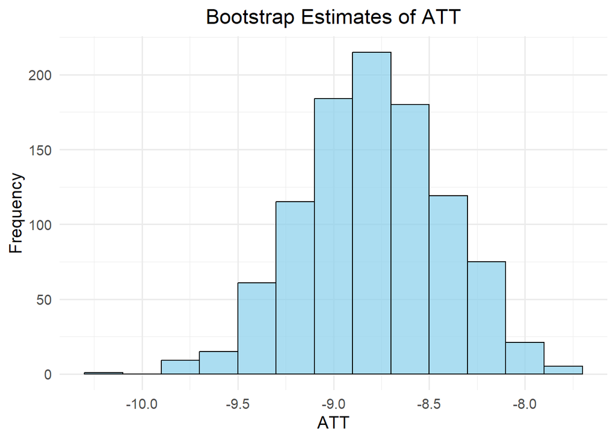

```r
# Plotting a histogram of your results.

# Converting the bootstrap_att results to a data frame for plotting
bootstrap_results = tibble(ATT = bootstrap_att)


bootstrap_results %>%
  ggplot(aes(x = ATT)) +
  geom_histogram(binwidth = 0.2, color = "black", fill = "skyblue", alpha = 0.7) +
  labs(
    title = "Bootstrap Estimates of ATT",
    x = "ATT",
    y = "Frequency"
  ) +
  theme_minimal(base_size = 14) +
  theme(
    plot.title = element_text(hjust = 0.5)
  )
```

```r
#Calculating the mean and 95% confidence intervals.


# the mean of the bootstrap ATT results
bootstrap_mean = mean(bootstrap_att)

# 95% confidence intervals (2.5th and 97.5th percentiles)
bootstrap_ci = quantile(bootstrap_att, probs = c(0.025, 0.975))


cat("Mean ATT:", bootstrap_mean, "\n")
```

```
## Mean ATT: -8.79111
```

```r
cat("95% Confidence Interval:", bootstrap_ci[1], "to", bootstrap_ci[2], "\n")
```

```
## 95% Confidence Interval: -9.499496 to -8.090881
```

It mostly depends on the goal that we are perusing in policy.if the goal is to implement a population-wide intervention by distributing mosquito nets to everyone. ATE provides the most comprehensive estimate of the overall benefit across the entire population.it could be good answer to if we scale up the intervention to everyone, how much benefit will we see on average?

ATT is the best for evaluating the effectiveness of an existing program.If we are deciding whether to continue, improve, or expand an existing intervention, the ATT is most relevant because it reflects the actual benefit for current users.it provides a good answer for how effective is the program for those who are already using the nets?

ATU is good for targeted interventions aimed at untreated groups. If the goal is to target untreated groups, the ATU is most relevant because it estimates the potential benefit for those who haven’t yet received the intervention. it is a good answer for what would happen if we provided nets to people who don’t currently use them?